# hw4

Ritika Agrawal

March 4, 2020

## Chick weights

The `ChickWeight` data set is part of the base package `datasets`. See `?ChickWeight` for details on the data. For all of the questions use `dplyr` functions with the pipe `%>%` whenever possible.

**Submission instructions**: Create a folder named `ds202_hw4`, and name the RMarkDown file including your solutions `hw4.Rmd` under this folder. For the submission, create a GitHub repository named `ds202_hw4` under your GitHub account, and push both `hw4.Rmd` and the knitted `hw4.html` before the deadline. I will assume you use the same GitHub username as for your HW3 submission. The latest version of your homework appearing on GitHub before the deadline is graded. *It is crucial to follow the exact folder structure and file names*. This homework is **due on March 4** before class.

```r
library("datasets")
library("dplyr")
```

```r
library(ggplot2)
head(ChickWeight,15)
```

```
##    weight Time Chick Diet
## 1      42    0     1    1
## 2      51    2     1    1
## 3      59    4     1    1
## 4      64    6     1    1
## 5      76    8     1    1
## 6      93   10     1    1
## 7     106   12     1    1
## 8     125   14     1    1
## 9     149   16     1    1
## 10    171   18     1    1
## 11    199   20     1    1
## 12    205   21     1    1
## 13     40    0     2    1
## 14     49    2     2    1
## 15     58    4     2    1
```

1. Get a frequency breakdown of the number of chicks, their average weight and the standard deviation of the weights in each of the diets at the start of the study. Store the resulting data frame in a variable named `weight0` and print.

```r
Chickweight0 <- ChickWeight %>%
  tbl_df() %>%
  select(Diet, Chick, weight)
weight0 <- Chickweight0 %>%
  tbl_df() %>%
  group_by(Diet) %>%
  summarise(chick_freq=n(),avg_weight = mean(weight),stdev_weight=sd(weight))
weight0
```

```
## # A tibble: 4 x 4
##   Diet  chick_freq avg_weight stdev_weight
##   <fct>      <int>      <dbl>        <dbl>
## 1 1            220       103.         56.7
## 2 2            120       123.         71.6
## 3 3            120       143.         86.5
## 4 4            118       135.         68.8
```

```
## geom_path: Each group consists of only one observation. Do you need to adjust
## the group aesthetic?
```

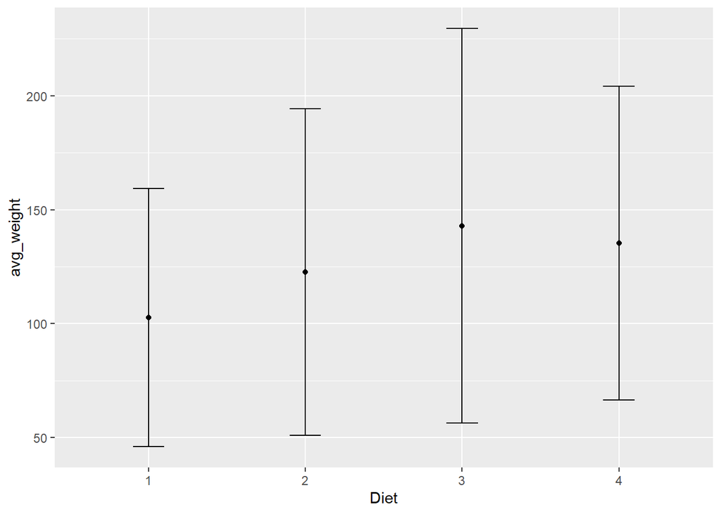

```r
ggplot(weight0,aes(x=Diet, y=avg_weight))+ geom_errorbar(aes(ymin=avg_weight-stdev_weight, ymax=avg_weight+stdev_weight), width=.2) + geom_line() + geom_point()
```

2. Each chick should have twelve weight measurements. Use the `dplyr` package to identify how many measurements are there for each chick. Extract a subset of the data for all chicks with complete information, name the data set `complete`, and print the first 3 rows. (Hint: you might want to use mutate to introduce a helper variable consisting of the number of observations)

```r
ChickWeight %>% nrow()
```

```
## [1] 578
```

```r
complete1 = ChickWeight
complete = ChickWeight
complete <- complete %>% group_by(Chick) %>% tally() %>% arrange(n)

complete ##When printing this out we see that chicks 8, 15, 16, 18 and 44 have incomplete data sets
```

```
## # A tibble: 50 x 2
##    Chick     n
##    <ord> <int>
##  1 18        2
##  2 16        7
##  3 15        8
##  4 44       10
##  5 8        11
##  6 13       12
##  7 9        12
##  8 20       12
##  9 10       12
## 10 17       12
## # ... with 40 more rows
```

```r
##removing incomplete data sets
complete1 <- complete1 %>% filter(Chick != "8")
complete1 <- complete1 %>% filter(Chick != "15")
complete1 <- complete1 %>% filter(Chick != "16")
complete1 <- complete1 %>% filter(Chick != "18")
complete1 <- complete1 %>% filter(Chick != "44")

complete = complete1 ##data set of Chicks with complete information

head(complete,3)
```

```
##   weight Time Chick Diet
## 1     42    0     1    1
## 2     51    2     1    1
## 3     59    4     1    1
```

3. In the complete data set introduce a new variable that measures the current weight difference compared to day 0. Name this variable `weightgain` and print the first 3 rows of the new data frame.

```r
#Function that finds the difference between the current weight compared to the weight at day 0
find_dif <- function(cur_weight, chick_num) {

  start_weight <- filter(complete, complete$Time == 0 & complete$Chick == chick_num)
  dif = (cur_weight) - (start_weight$weight)
  return(dif)
}
#Add a column called Weight Gain
complete$Weight_Gain <- find_dif(complete$weight,complete$Chick)
complete
```

```
##     weight Time Chick Diet Weight_Gain
## 1       42    0     1    1           0
## 2       51    2     1    1          11
## 3       59    4     1    1          16
## 4       64    6     1    1          22
## 5       76    8     1    1          35
## 6       93   10     1    1          52
## 7      106   12     1    1          65
## 8      125   14     1    1          83
## 9      149   16     1    1         108
## 10     171   18     1    1         128
## 11     199   20     1    1         158
## 12     205   21     1    1         164
## 13      40    0     2    1          -1
## 14      49    2     2    1           7
```

[output cut: 526 more lines]

4. Use `{ggplot2}` to create side-by-side boxplots of `weightgain` by `Diet` for day 21. Change the order of the categories in the Diet variable such that the boxplots are ordered by median `weightgain`, and the lower limit of the y axis should be 0. Describe the relationship in 2-3 sentences.

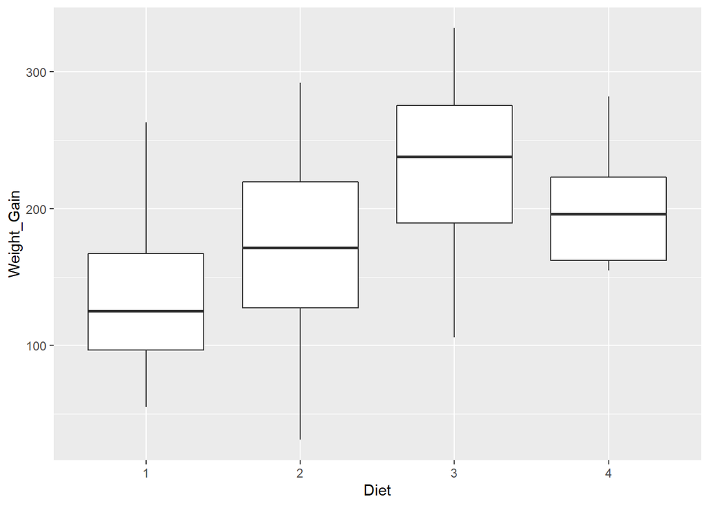

```r
#Filter data from day 21
weightgain <- filter(complete, complete$Time==21)

weightgain %>% ggplot(aes(x = Diet, y = Weight_Gain)) + geom_boxplot()
```

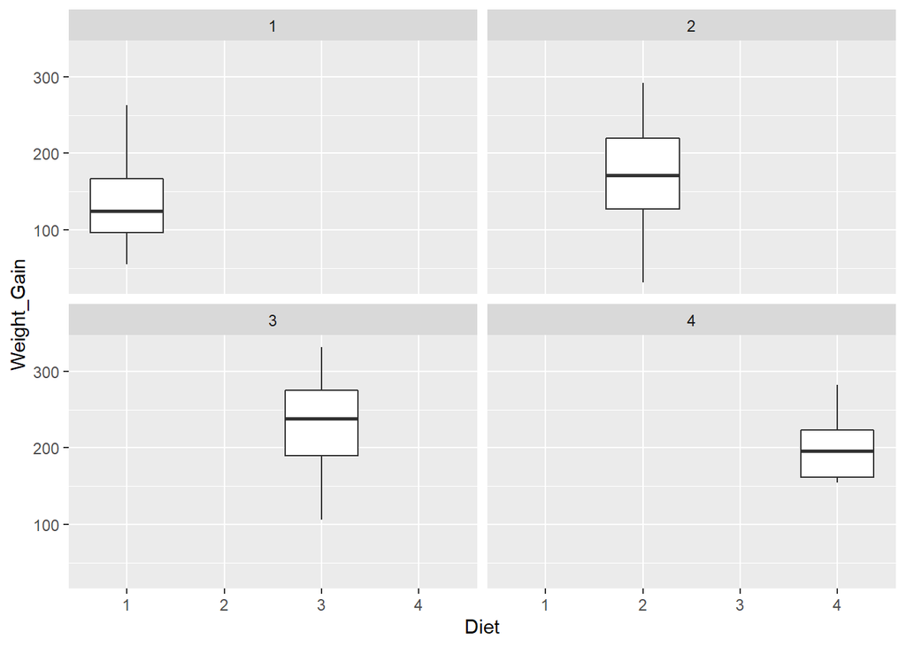

```r
weightgain %>% ggplot(aes(x = Diet, y = Weight_Gain)) + geom_boxplot()+
    facet_wrap(~Diet)
```

5. Answer each of the following questions using numerical and graphical summary. Also explain what you found: (a) Which chick gained the most weight and which gained the least weight? (b) What diets were they on?

```r
##To determine which chick gained most weight
max = max(complete$Weight_Gain, na.rm = TRUE)
max
```

```
## [1] 332
```

```r
complete[complete$Weight_Gain==max,"Chick"]
```

```
## [1] 35
## 50 Levels: 18 < 16 < 15 < 13 < 9 < 20 < 10 < 8 < 17 < 19 < 4 < 6 < 11 < ... < 48
```

```r
complete[complete$Weight_Gain==max,"Diet"] ## Gives what Diet the chick was on
```

```
## [1] 3
## Levels: 1 2 3 4
```

```r
##To determine which chick gained least weight
min = min(complete$Weight_Gain, na.rm = TRUE)
min
```

```
## [1] -4
```

```r
complete[complete$Weight_Gain==min,"Chick"]
```

```
## [1] 29 48
## 50 Levels: 18 < 16 < 15 < 13 < 9 < 20 < 10 < 8 < 17 < 19 < 4 < 6 < 11 < ... < 48
```

```r
complete[complete$Weight_Gain==min,"Diet"] ## Gives what Diet the chick was on
```

```
## [1] 2 4
## Levels: 1 2 3 4
```

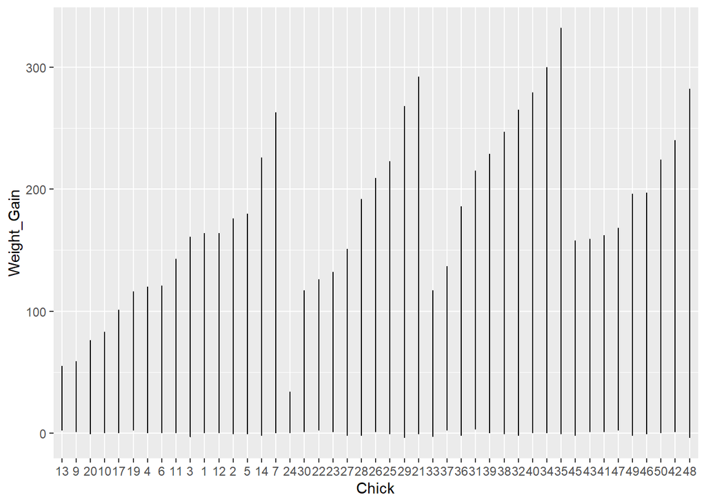

```r
complete %>% ggplot(aes(x = Chick, y = Weight_Gain)) + geom_line()
```

6. For the chicks with the least and the most weight at time 0, plot their growth trajectories over time.

```r
mostleastweight <- filter(complete, complete$Time==0)
mostleastweight
```

```
##    weight Time Chick Diet Weight_Gain
## 1      42    0     1    1           0
## 2      40    0     2    1          -1
## 3      43    0     3    1           4
## 4      42    0     4    1           0
## 5      41    0     5    1          -1
## 6      41    0     6    1           0
## 7      41    0     7    1           0
## 8      42    0     9    1           1
## 9      41    0    10    1           0
## 10     43    0    11    1           0
## 11     41    0    12    1           0
## 12     41    0    13    1           2
## 13     41    0    14    1          -2
## 14     42    0    17    1           0
```

[output cut: 31 more lines]

```r
max = max(mostleastweight$weight, na.rm = TRUE) ## Gives the maximum weight at time 0
max
```

```
## [1] 43
```

```r
most <- mostleastweight[mostleastweight$weight==max,"Chick"] ##Gives chicks with most weight at time 0
most
```

```
## [1] 3  11 19 23
## 50 Levels: 18 < 16 < 15 < 13 < 9 < 20 < 10 < 8 < 17 < 19 < 4 < 6 < 11 < ... < 48
```

```r
min = min(mostleastweight$weight, na.rm = TRUE) ## Gives the minimum weight at time 0
min
```

```
## [1] 39
```

```r
least <- mostleastweight[mostleastweight$weight==min,"Chick"] ##Gives chicks with least weight at time 0
least
```

```
## [1] 27 28 29 33 36 48
## 50 Levels: 18 < 16 < 15 < 13 < 9 < 20 < 10 < 8 < 17 < 19 < 4 < 6 < 11 < ... < 48
```

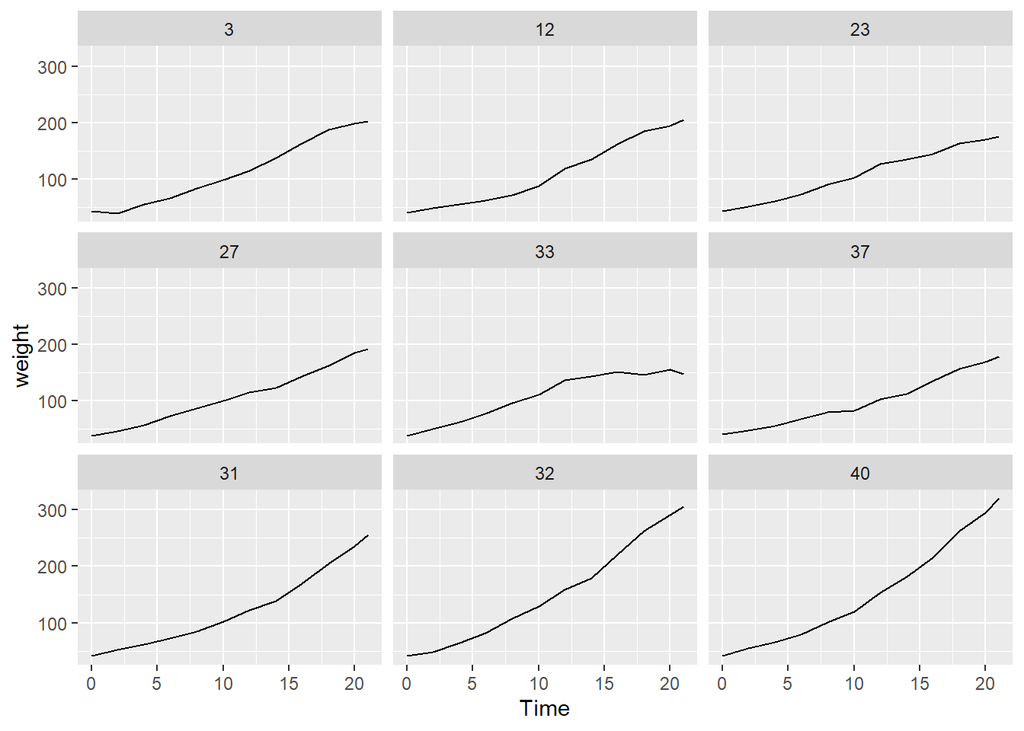

```r
partial <- complete[complete$Chick %in% c(3,12,23,27,31,32,33,37,40), ]

ggplot(data = partial, aes(x = Time, y = weight)) + geom_line() +
    facet_wrap(~Chick)
```

7. Add to the previous plot the average growth trajectory for all chicks (calculated as the mean weight for each chick at each time). How do the trajectories compare?

```r
##Compute the average weight of all chicks across time
mean <- complete %>%
  group_by(Time) %>%
  summarise(mean_weight = mean(weight))
mean
```

```
## # A tibble: 12 x 2
##     Time mean_weight
##    <dbl>       <dbl>
##  1     0        41.1
##  2     2        49.6
##  3     4        60.2
##  4     6        74.9
##  5     8        92.4
##  6    10       110.
##  7    12       133.
##  8    14       146.
##  9    16       170.
## 10    18       192.
## 11    20       212.
## 12    21       219.
```

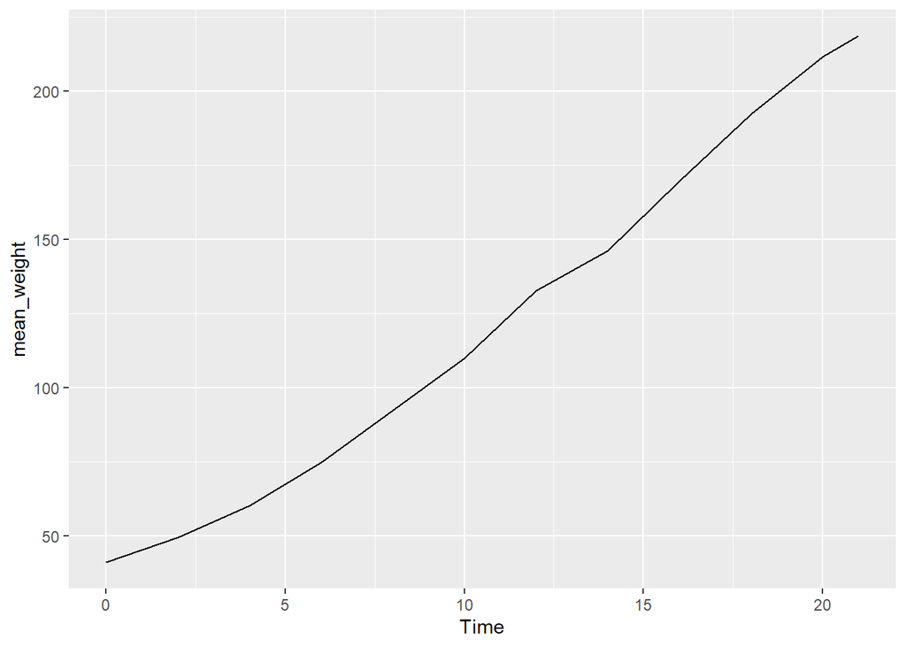

```r
ggplot(mean,aes(x=Time, y=mean_weight), color=Diet) + geom_line()
```

8. What else do you find interesting in the dataset? Show your exploratory analysis.

```r
full <- complete %>%
  group_by(Diet, Time) %>%
  summarise(mean_weight = mean(weight))
mean
```

```
## # A tibble: 12 x 2
##     Time mean_weight
##    <dbl>       <dbl>
##  1     0        41.1
##  2     2        49.6
##  3     4        60.2
##  4     6        74.9
##  5     8        92.4
##  6    10       110.
##  7    12       133.
##  8    14       146.
##  9    16       170.
## 10    18       192.
## 11    20       212.
## 12    21       219.
```

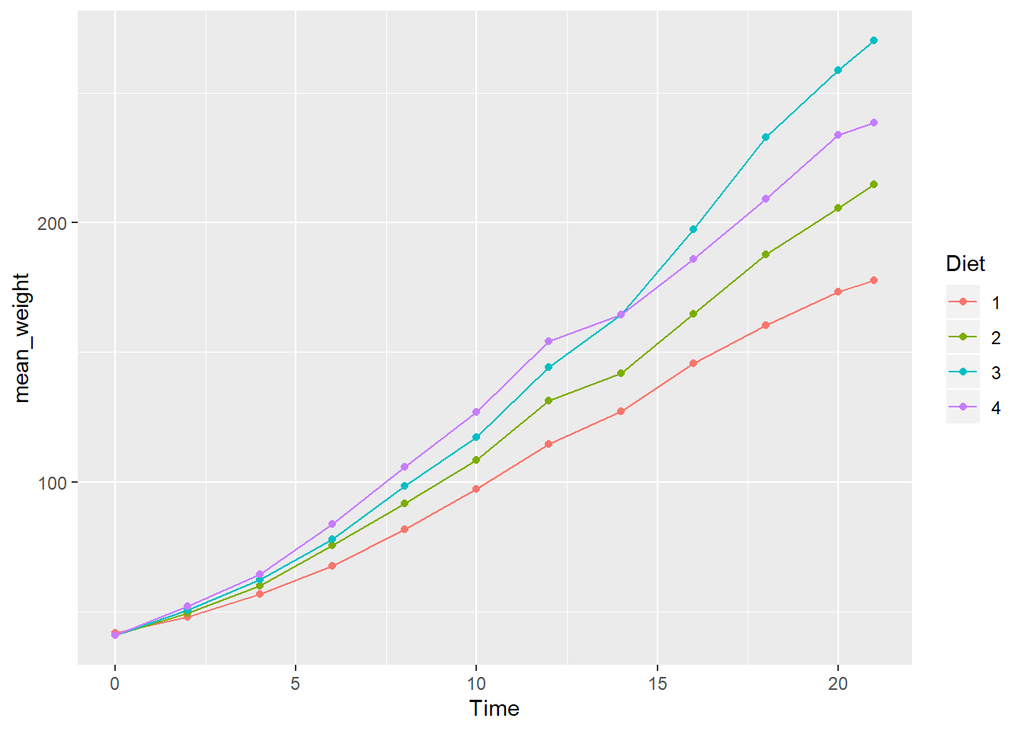

```r
ggplot(full,aes(x=Time, y=mean_weight, color=Diet)) + geom_line() + geom_point() + scale_colour_discrete(name = "Diet", label = c("1","2","3","4"))
```

Response: I have plotted the growth trajectory of the mean weight for each diet. As can be seen from the graph, the mean weight for Diet 3 is lower than Diet 4 but suddenly increases and crosses the mean weight of Diet 4 after around time 14.

Note: your submission is supposed to be fully reproducible, i.e. the TA and I will ‘knit’ your submission in RStudio.